# Habitat quelques chiffres

B. Maranget

2026-04-07

# 1 Objet

La Direction de l’Habitat cherche à avoir quelques chiffres repères sur Bondy.

3 sources principales sont consultées :

- [ANCT Observatoire des territoires](https://www.observatoire-des-territoires.gouv.fr/outils/cartographie-interactive/#view=map76&c=indicator)
- INSEE enquête filosofi insee déclinée en fichier [Niveau de vie médian et taux de pauvreté par statut d’occupation du logement](https://catalogue-donnees.insee.fr/fr/catalogue/recherche/DS_FILOSOFI_LOG_TP_NIVVIE)
- [RPLS](https://www.data.gouv.fr/datasets/donnees-detaillees-au-logement-du-repertoire-des-logements-locatifs-des-bailleurs-sociaux-rpls) (producteur SDES *Service des données et études statistiques* sur data.gouv)

De façon complémentaire :

- [Insee démographie](https://www.insee.fr/fr/statistiques/3698339#consulter)
- [Drihl, Direction Régionalee et Interdépartementale de l’Hébergement et du Logement](https://data-drihl.developpement-durable.gouv.fr/#c=indicator&i=lls_rpls_caract.lls_plai&s=2025&view=map2)
- [Ma demande de logement social](https://www.demande-logement-social.gouv.fr/index)

# 2 Population totale

## 2.1 Evolution : chiffres insee

Il existe une tendance à la baisse depuis 2019 (de 55 000 à 50 000 environ).

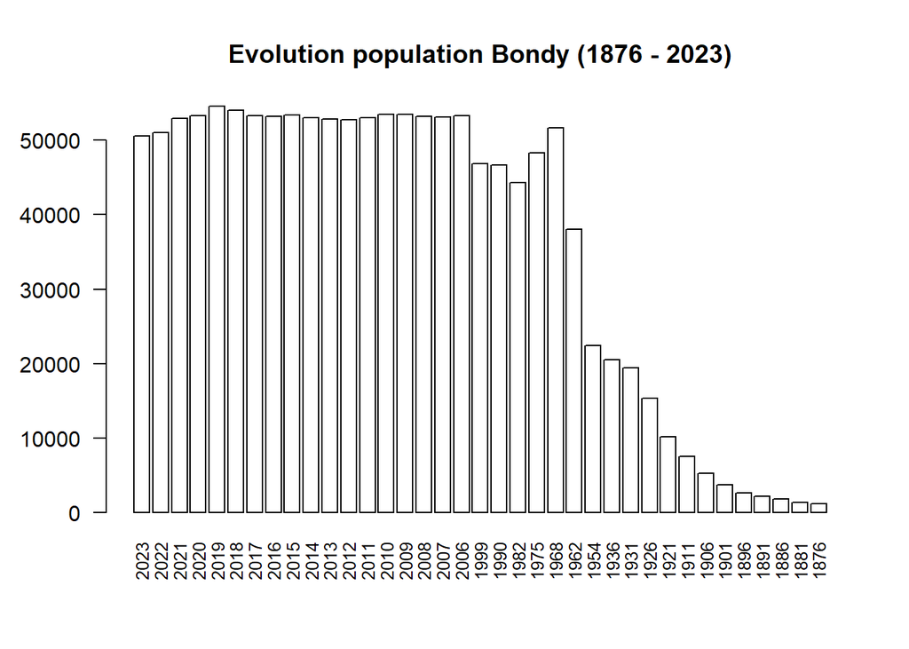

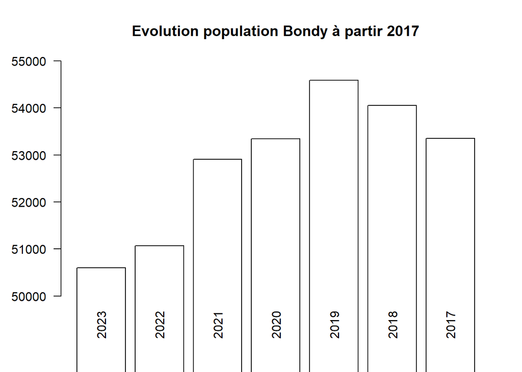

| année | nb |
| --- | --- |
| 2023 | 50595 |
| 2022 | 51066 |
| 2021 | 52905 |
| 2020 | 53342 |
| 2019 | 54587 |
| 2018 | 54055 |
| 2017 | 53353 |

## 2.2 Ril 2025

Le ril (Répertoire Immeuble Localisé) indique le nombre d’habitats, même en multipliant par 2, le chiffre obtenu est supérieur aux chiffres insee.

| numero | repetition | complement | type_voie | libelle | nombre_logements | numero_parcelle |
| --- | --- | --- | --- | --- | --- | --- |
| 19 |  |  | ALL | DE LA VILLA JEANNETTE | 1 | AN0055 |
| 2 |  | BAT D | R | BENOITE GROULT | 29 | 0H0415 |
| 26 |  |  | R | DU BON AIR | 2 | 0B0211 |
| 25 |  |  | R | DU CYCLE | 1 | 0T0029 |
| 3 |  |  | R | BORDIER | 6 | AL0118 |
| 5 |  |  | ALL | ANNE SYLVESTRE | 1 | 0A0378 |

```
## [1] 56150
```

A appprondir, pourquoi l’estimation à partir du RIL donne plus d’habitants que le chiffre INSEE de 2023 ?

# 3 Indicateurs sociaux globaux

## 3.1 Seuil de pauvreté

| Mesures.filosofi | Valeur |
| --- | --- |
| Taux de pauvreté (en %) au seuil de 60 % de la médiane du niveau de vie | 34 |

## 3.2 Logements sociaux

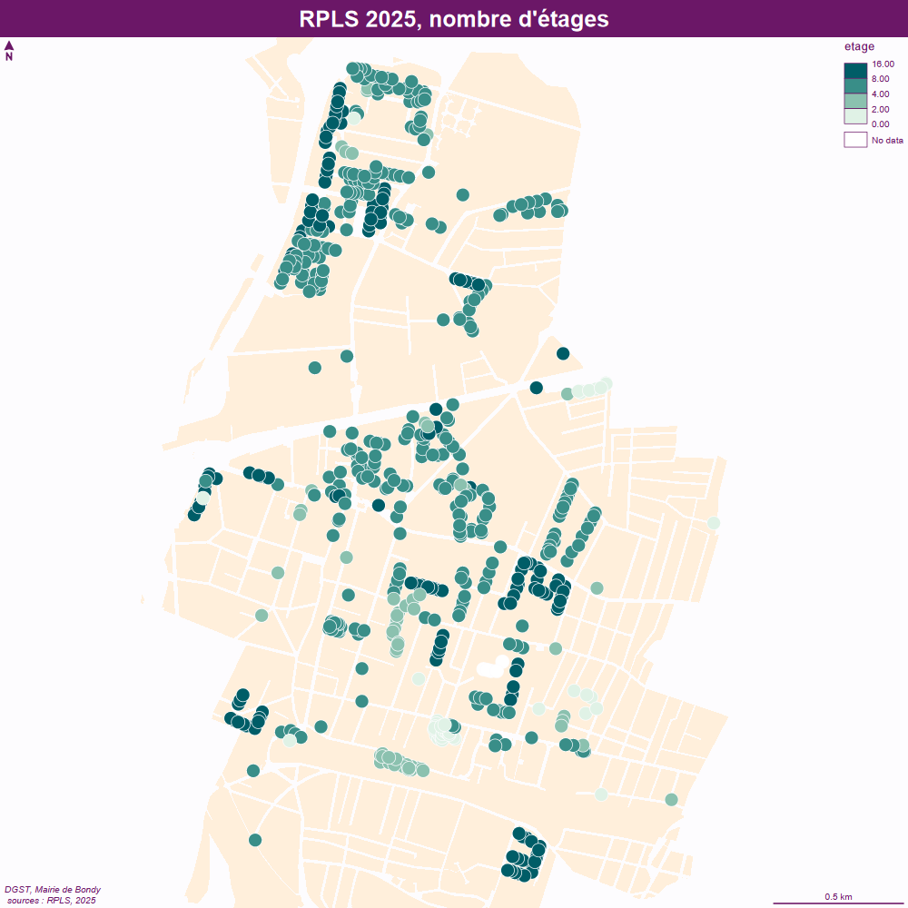

Nb de logements sociaux

[output not shown]

| Nb étages | Nb immeubles |
| --- | --- |
| 0 | 48 |
| 1 | 2 |
| 2 | 11 |
| 3 | 56 |
| 4 | 180 |
| 5 | 149 |
| 6 | 29 |
| 7 | 2 |
| 8 | 18 |
| 9 | 37 |
| 10 | 79 |
| 12 | 39 |
| 15 | 1 |
| 18 | 5 |

A noter, Marx Dormoy / ZAC de l’Ourcq / Sablière / allée Laffargue

# 4 Typologie occupation logements

En pourcentage du nb de logement total

| proprio 2022 | Locataires 2022 | HLM | RPLS 2023 | RP 2022 | vacants | vacants 2 ans + |
| --- | --- | --- | --- | --- | --- | --- |
| 35 | 20 | 34 | 44 | 89 | 10 | 2 |

# 5 Disparités territoriales

Croisement de deux sources Insee Filosofi (tx pauvreté) et ANCT (rpls)

% de logement social / % de la population sous le seuil de pauvreté

Plus le chiffre est élevé, plus l’offre en logement social répond aux besoins de la taille de la population modeste.

| ville | rapport |
| --- | --- |
| Bagnolet | 70 |
| Bondy | 77 |
| Le Pré Saint Gervais | 56 |
| Romainville | 71 |

Cartographie

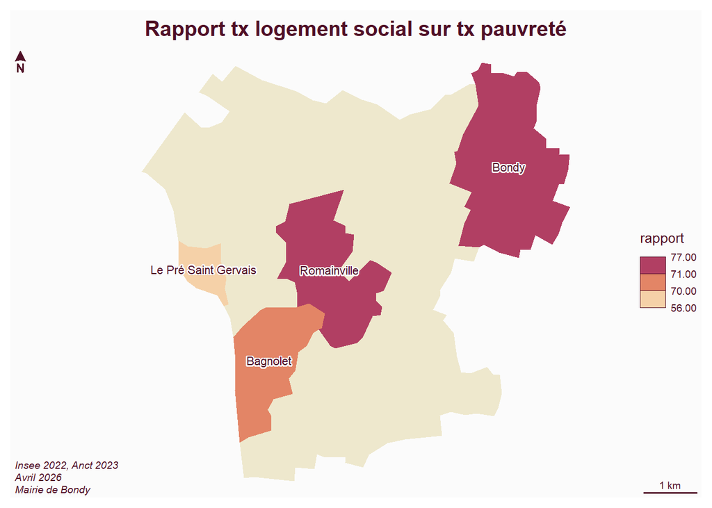

# 6 Traitement des demandes de logement social

## 6.1 Nombre de demandes

```
## [1] "4693 demandes en attente sur Bondy"
```

drihl

```
## [1] "Délai médian d'attribution 2024 : 33.8"
```

## 6.2 PLAI

```
##
##   10   13   14   16 <NA>
##   87  212  287   21 9099
```

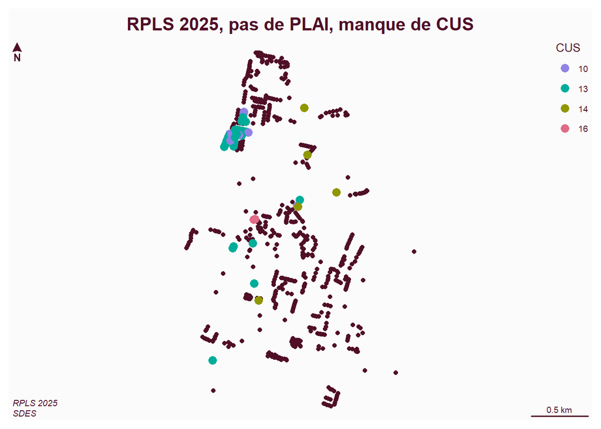

CUS 10 = PLA d’intégration

CUS 13 = 13.PLUS

CUS 14 = PLS / PPLS / PLA CFF

CUS 16 = 16.PLI

Sur le site de la Drihl Ile de France, il existe des chiffres sur le financement initial.

```
## [1] "Nb de plai 2025 : 361"
```

## 6.3 DALO

### 6.3.1 Au département

```
##              dpt nb.favorable nb.réalité
## 6 Seine St Denis         4646       2379
```

### 6.3.2 Sur Bondy, la drihl

```
## [1] "Nb d'attributions DALO 2024 : 109"
```

## 6.4 Logement indigne (au dpt)

### 6.4.1 Au dpt

```
##
##                         Procédure d'insalubrité remédiable ou irrémédiable
##                                                                        429
##               Procédure d'urgence d'insalubrité remédiable ou irrémédiable
##                                                                         17
##                  Procédure désordre ponctuel présentant un danger imminent
##                                                                        125
## Procédure relative aux locaux dangereux par l'utilisation qui en est faite
##                                                                         32
##                             Procédure relative aux locaux en suroccupation
##                                                                         25
##                     Procédure relative aux locaux impropres à l'habitation
##                                                                        311
##                                                       Procédure saturnisme
##                                                                        572
```

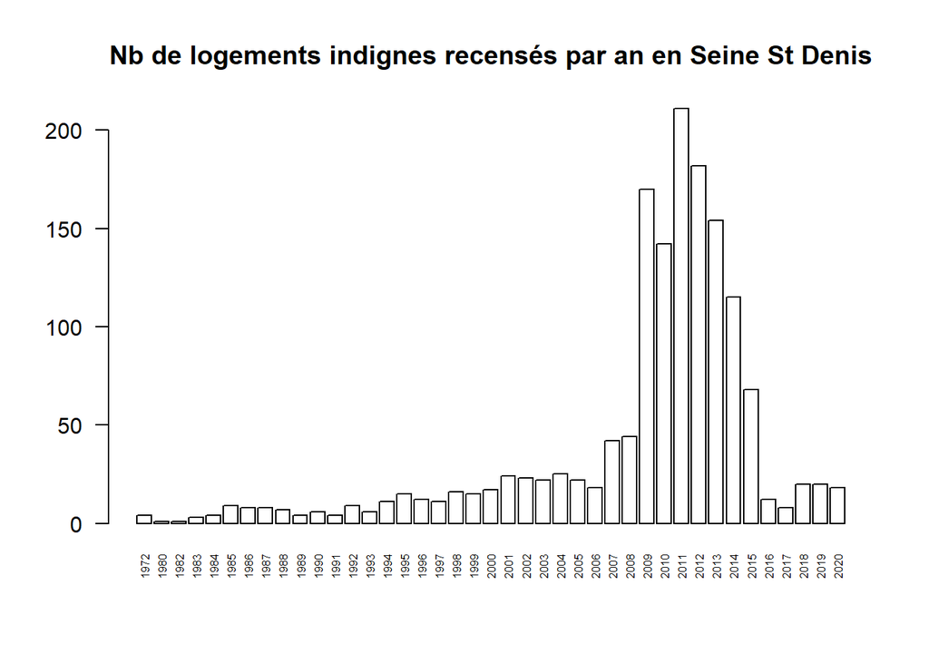

Pas de donnée sur Bondy, quel est le cheminement des arrêtés de péril ?

### 6.4.2 Copro aidées (rnic)

| nom_d_usage_de_la_copropriete | nombre_total_de_lots |
| --- | --- |
| LA BRUYERE | 525 |
| 38/40 RUE ETIENNE DOLET | 120 |
| L’ERMITAGE | 199 |
| SDC LES PEUPLIERS | 154 |
| VILLA CHOPIN VOL. 1 | 99 |
| VILLA ENEA - MS12923 | 42 |
| SDC 15 AV DES SCIENCES | 13 |
| SDC COEUR DE BONDY | 69 |

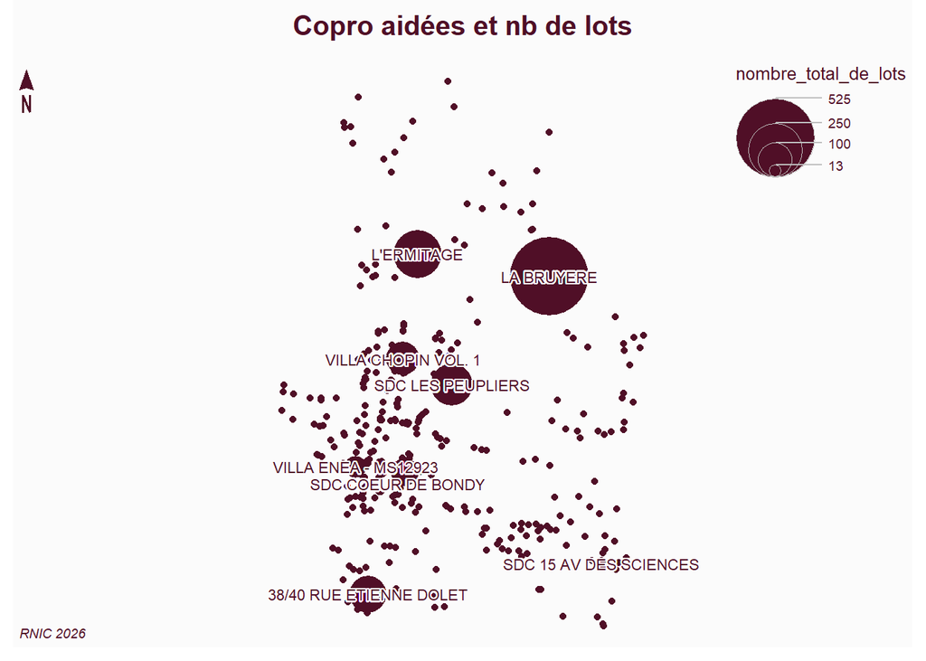

```
## The scale bar does not work on unprojected (long/lat) maps.
```